# Lab: Machine Learning I

In this lab, we will practice working with machine learning terminology and modeling approaches for classification. We will fit logistic regression and a Naive Bayes classifier to breast cancer biopsy data from the University of Wisconsin. This dataset is available as `brca` in the `dslabs` package and is also part of the UCI Machine Learning Repository. `brca` is a binary classification dataset for 569 malignant (cancer) and benign (not cancer) breast masses. 30 continuous features were computationally extracted from digital images of fine needle aspirate biopsy slides.

```r
library(tidyverse)
library(caret)
library(e1071)

library(dslabs)
data(brca)
```

For simplicity, let’s focus on only the first two predictors, `radius_mean` and `texture_mean`. In the code chunk below, we construct a data frame called `dat` with three variables:

- `labels`: a factor with two levels denoting whether a mass is “Benign” or “Malignant”.
- `radius_mean`: the mean nucleus radius
- `texture_mean`: the mean nucleus texture

```r
dat = data.frame(labels = factor(ifelse(brca$y == "B", "Benign", "Malignant")),
                 radius_mean = brca$x[,"radius_mean"],
                 texture_mean = brca$x[,"texture_mean"])
```

Here, we use the `createDataPartition` function from the `caret` package to randomly split the data into training and test datasets. Setting `p = 0.5` creates training and test datasets of (approximately) equal sizes. `set.seed(260)` ensures reproducibility, so that we get the same random split every time.

```r
set.seed(260)
index_train = createDataPartition(y = dat$labels,
                                  times = 1, p = 0.5, list = FALSE)
train_set = slice(dat, index_train)
test_set = slice(dat, -index_train)
```

1. Before doing any model fitting, it is always a good idea to perform some exploratory data analysis. Based on the training set, calculate descriptive statistics and make plots to help you get a better sense of the data. In particular, use your explorations to comment on the prevalence of the outcome, the relationships between the variables, and anything that you would consider unusual.

**Solution:**

(Note that this solution is non-exhaustive, and that there are many other things that you could do as part of your EDA.)

Here’s a quick way to get summary statistics for every variable in the data frame.

```r
train_set %>% summary()
```

```
##        labels     radius_mean      texture_mean
##  Benign   :179   Min.   : 6.981   Min.   : 9.71
##  Malignant:106   1st Qu.:11.690   1st Qu.:15.90
##                  Median :13.480   Median :18.70
##                  Mean   :14.192   Mean   :19.19
##                  3rd Qu.:15.850   3rd Qu.:21.80
##                  Max.   :28.110   Max.   :31.12
```

There is a lower prevalence of malignant masses (0.3719) compared to benign masses in this dataset.

```r
train_set %>%
  summarize(pi = mean(labels=="Malignant")) %>%
  .$pi
```

```
## [1] 0.3719298
```

Histograms can give us a quick snapshot of the univariate distributions of the two continuous predictors. `radius_mean` and `texture_mean` look roughly unimodal and symmetric, although both have a longer right tail/are skewed right.

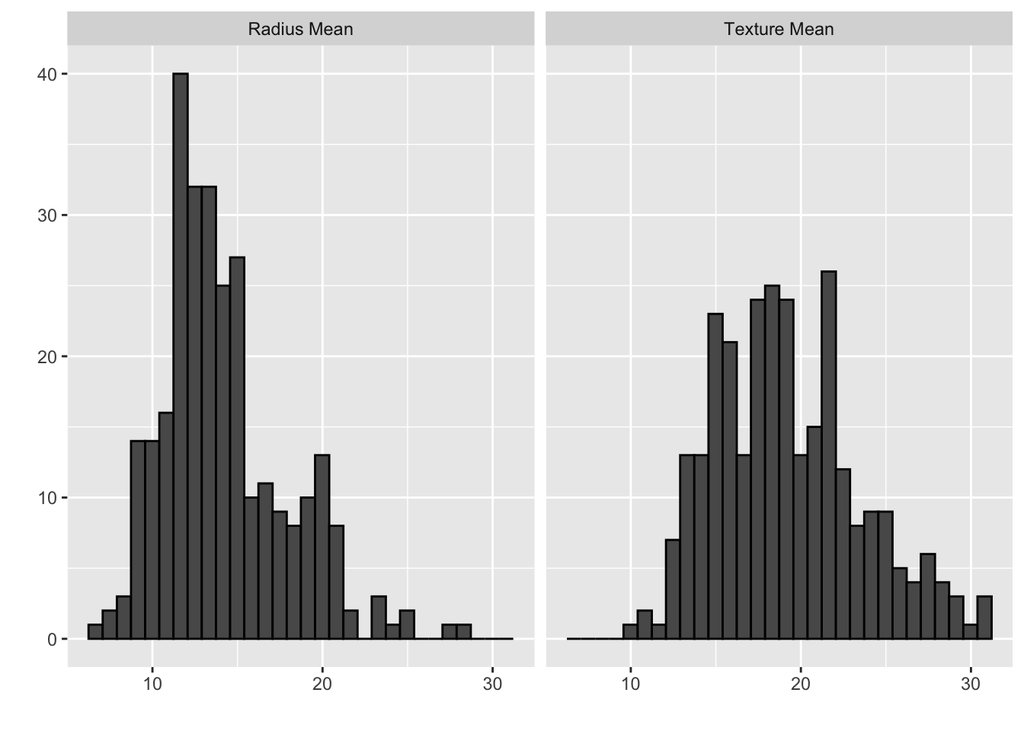

```r
train_set %>%
  gather(feature_name, measurement, c("radius_mean", "texture_mean"))  %>%
  ggplot(aes(measurement)) +
  geom_histogram(color = "black") +
  facet_wrap(~ feature_name,
             labeller = as_labeller(c("radius_mean"="Radius Mean",
                                      "texture_mean" = "Texture Mean"))) +
  xlab("") + ylab("")
```

These side-by-side boxplots suggest that malignant masses generally correspond to higher values of both the `radius_mean` and `texture_mean` variables.

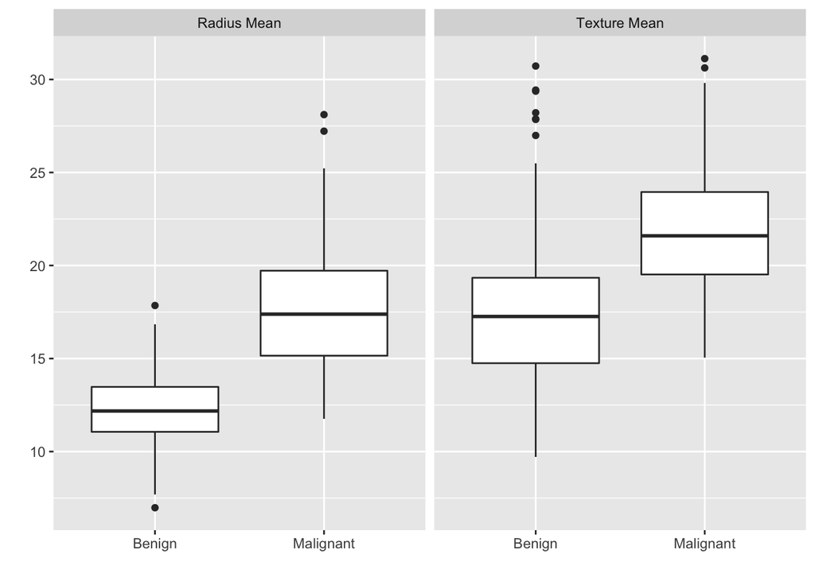

```r
train_set %>%
  gather(feature_name, measurement, c("radius_mean", "texture_mean"))  %>%
  ggplot(aes(x = labels, y = measurement)) +
  geom_boxplot() +
  facet_wrap(~ feature_name,
             labeller = as_labeller(c("radius_mean"="Radius Mean",
                                      "texture_mean" = "Texture Mean"))) +
  xlab("") + ylab("")
```

Instead of making boxplots, we can visualize the outcome and predictors in a single plot by making good use of color. This scatterplot graphs `texture_mean` against `radius_mean` and colors the points according to the outcome labels. The two different classes form distinct, but not totally separable groups of points. Some observations look like they might be difficult to classify.

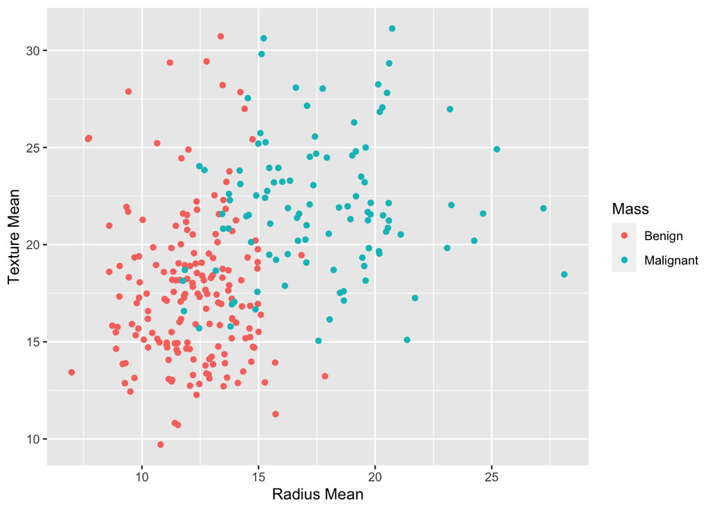

```r
train_set %>%
  ggplot(aes(x = radius_mean, y = texture_mean, color = labels)) +
  geom_point() +
  scale_color_discrete(name = "Mass") +
  xlab("Radius Mean") + ylab("Texture Mean")
```

2. Using the `glm` function, fit a logistic regression model to the training set that predicts `labels` based on `radius_mean` and `texture_mean`. Don’t forget to set `family = "binomial"`. Then, use the `predict` function (with `type="response"`) to get probability estimates for the test set, and convert the probabilities to predicted response labels (use a cutoff of 0.5).

   Obtain the accuracy, confusion matrix, and other relevant diagnostic statistics for the test set. Explain what the confusion matrix and the sensitivity/specificity are telling you about the types of errors that your model is making.

**Solution:**

```r
# To make everything easier/consistent, let's recode "Benign" and "Malignant" to 0 and 1 respectivily.

train_set <- train_set %>% mutate(labels_numeric = ifelse(labels == "Malignant", 1, 0))
test_set <- test_set %>% mutate(labels_numeric = ifelse(labels == "Malignant", 1, 0))

fit_logistic = glm(labels_numeric ~ radius_mean + texture_mean,
                   data = train_set, family = "binomial")

p_hat_logistic = predict(fit_logistic, newdata = test_set, type = "response")
y_hat_logistic = factor(ifelse(p_hat_logistic > 0.5, 1, 0))

confusionMatrix(data = y_hat_logistic,
                reference = as.factor(test_set$labels_numeric))
```

```
## Confusion Matrix and Statistics
##
##           Reference
## Prediction   0   1
##          0 167  24
##          1  11  82
##
##                Accuracy : 0.8768
##                  95% CI : (0.8328, 0.9126)
##     No Information Rate : 0.6268
##     P-Value [Acc > NIR] : < 2e-16
##
##                   Kappa : 0.7299
##
##  Mcnemar's Test P-Value : 0.04252
##
##             Sensitivity : 0.9382
##             Specificity : 0.7736
##          Pos Pred Value : 0.8743
##          Neg Pred Value : 0.8817
##              Prevalence : 0.6268
##          Detection Rate : 0.5880
##    Detection Prevalence : 0.6725
##       Balanced Accuracy : 0.8559
##
##        'Positive' Class : 0
##
```